# 红葡萄酒数据分析

本文档使用优达学诚提供的“红葡萄酒质量”数据集来进行分析。数据集概述：这个整齐的数据集包含 1,599 种红酒，以及 11 个关于酒的化学成分的变量。至少 3 名葡萄酒专家对每种酒的质量进了评分，分数在 0（非常差）和10（非常好）之间。 此数据集的来源： P. Cortez, A. Cerdeira, F. Almeida, T. Matos and J. Reis. Modeling wine preferences by data mining from physicochemical properties. In Decision Support Systems, Elsevier, 47(4):547-553. ISSN: 0167-9236.

# Univariate Plots Section 单变量绘图部分

```
## [1] 1599   13
```

```
## 'data.frame':    1599 obs. of  13 variables:
##  $ X                   : int  1 2 3 4 5 6 7 8 9 10 ...
##  $ fixed.acidity       : num  7.4 7.8 7.8 11.2 7.4 7.4 7.9 7.3 7.8 7.5 ...
##  $ volatile.acidity    : num  0.7 0.88 0.76 0.28 0.7 0.66 0.6 0.65 0.58 0.5 ...
##  $ citric.acid         : num  0 0 0.04 0.56 0 0 0.06 0 0.02 0.36 ...
##  $ residual.sugar      : num  1.9 2.6 2.3 1.9 1.9 1.8 1.6 1.2 2 6.1 ...
##  $ chlorides           : num  0.076 0.098 0.092 0.075 0.076 0.075 0.069 0.065 0.073 0.071 ...
##  $ free.sulfur.dioxide : num  11 25 15 17 11 13 15 15 9 17 ...
##  $ total.sulfur.dioxide: num  34 67 54 60 34 40 59 21 18 102 ...
##  $ density             : num  0.998 0.997 0.997 0.998 0.998 ...
##  $ pH                  : num  3.51 3.2 3.26 3.16 3.51 3.51 3.3 3.39 3.36 3.35 ...
##  $ sulphates           : num  0.56 0.68 0.65 0.58 0.56 0.56 0.46 0.47 0.57 0.8 ...
##  $ alcohol             : num  9.4 9.8 9.8 9.8 9.4 9.4 9.4 10 9.5 10.5 ...
##  $ quality             : int  5 5 5 6 5 5 5 7 7 5 ...
```

```
##        X          fixed.acidity   volatile.acidity  citric.acid
##  Min.   :   1.0   Min.   : 4.60   Min.   :0.1200   Min.   :0.000
##  1st Qu.: 400.5   1st Qu.: 7.10   1st Qu.:0.3900   1st Qu.:0.090
##  Median : 800.0   Median : 7.90   Median :0.5200   Median :0.260
##  Mean   : 800.0   Mean   : 8.32   Mean   :0.5278   Mean   :0.271
##  3rd Qu.:1199.5   3rd Qu.: 9.20   3rd Qu.:0.6400   3rd Qu.:0.420
##  Max.   :1599.0   Max.   :15.90   Max.   :1.5800   Max.   :1.000
##  residual.sugar     chlorides       free.sulfur.dioxide
##  Min.   : 0.900   Min.   :0.01200   Min.   : 1.00
##  1st Qu.: 1.900   1st Qu.:0.07000   1st Qu.: 7.00
##  Median : 2.200   Median :0.07900   Median :14.00
##  Mean   : 2.539   Mean   :0.08747   Mean   :15.87
##  3rd Qu.: 2.600   3rd Qu.:0.09000   3rd Qu.:21.00
##  Max.   :15.500   Max.   :0.61100   Max.   :72.00
##  total.sulfur.dioxide    density             pH          sulphates
##  Min.   :  6.00       Min.   :0.9901   Min.   :2.740   Min.   :0.3300
##  1st Qu.: 22.00       1st Qu.:0.9956   1st Qu.:3.210   1st Qu.:0.5500
##  Median : 38.00       Median :0.9968   Median :3.310   Median :0.6200
##  Mean   : 46.47       Mean   :0.9967   Mean   :3.311   Mean   :0.6581
##  3rd Qu.: 62.00       3rd Qu.:0.9978   3rd Qu.:3.400   3rd Qu.:0.7300
##  Max.   :289.00       Max.   :1.0037   Max.   :4.010   Max.   :2.0000
##     alcohol         quality
##  Min.   : 8.40   Min.   :3.000
##  1st Qu.: 9.50   1st Qu.:5.000
##  Median :10.20   Median :6.000
##  Mean   :10.42   Mean   :5.636
##  3rd Qu.:11.10   3rd Qu.:6.000
##  Max.   :14.90   Max.   :8.000
```

#### **质量分数直方图**

首先，我想了解一下1599种红葡萄酒质量分数的分布：

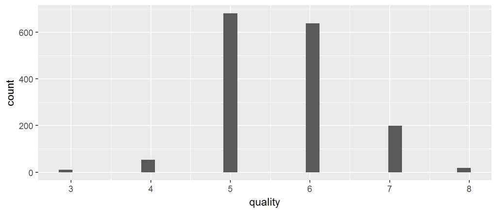

```
##    Min. 1st Qu.  Median    Mean 3rd Qu.    Max.
##   3.000   5.000   6.000   5.636   6.000   8.000
```

```
##
##   3   4   5   6   7   8
##  10  53 681 638 199  18
```

我通过直方图得知大部分红酒的得分在5或6分，最大8分，最小3分。3分只有10个，8分只有18个。  
下面，画出所有输入变量（2~12项）的直方图。

#### **“fixed.acidity” 酒石酸**

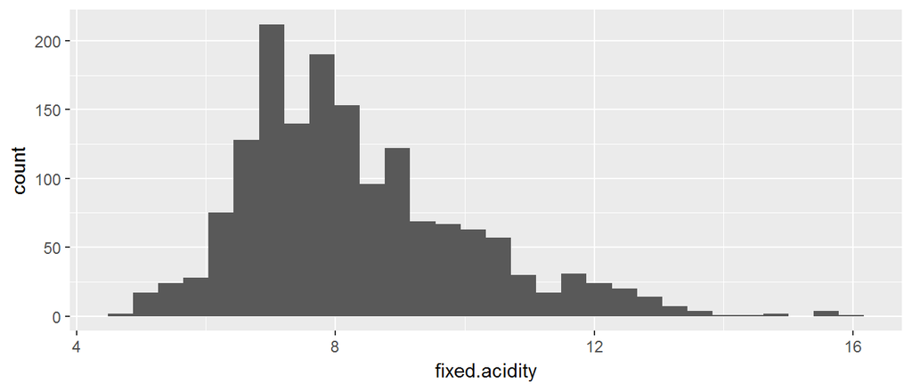

上图为正偏斜分布

#### **“volatile acidity” 醋酸**

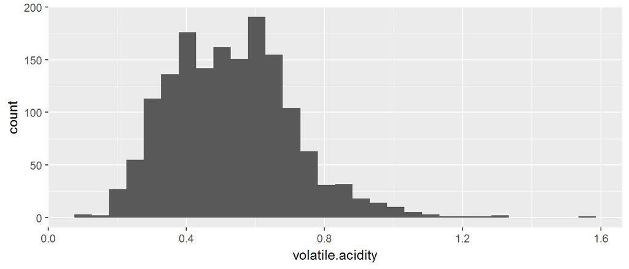

上图为正偏斜分布

#### **“citric.acid” 柠檬酸**

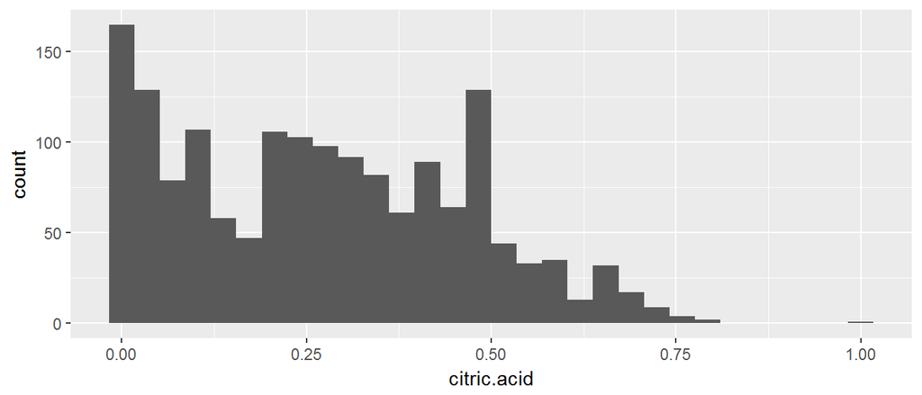

上图0位置附近和0.5附近的数据最密集，将柱宽改为0.01，如下图所示：

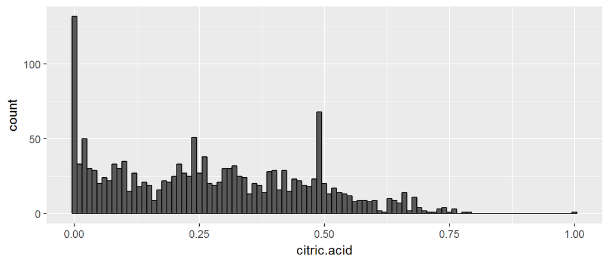

```
##
## FALSE  TRUE
##  1467   132
```

```
##
## FALSE  TRUE
##  1531    68
```

132种红酒的柠檬酸含量为0；  
68种红酒柠檬酸含量为0.49g/dm^3  
柠檬酸的含量为0，是否是数据有问题呢？我还想了解一下柠檬酸含量为0的红酒的质量分数分布。

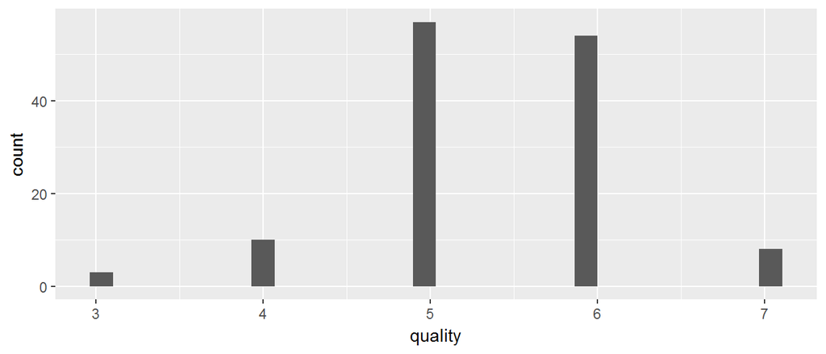

```
##
##  3  4  5  6  7
##  3 10 57 54  8
```

上图可知，柠檬酸含量为0的红酒低分较多，比如有3个3分，10个4分，而整体的红酒中只有10个3分，53个4分。

#### “residual.sugar” 残留糖

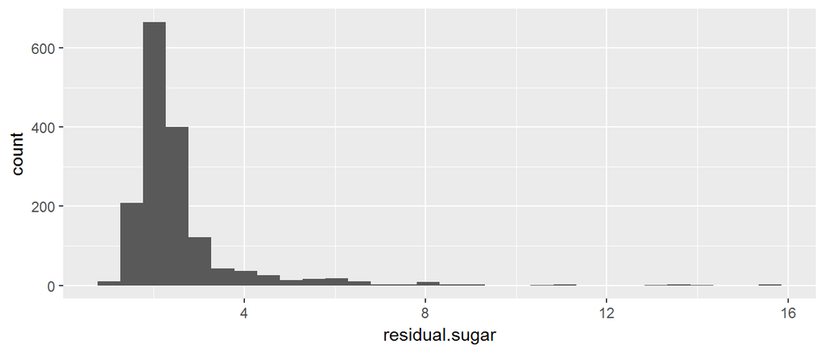

```
##    Min. 1st Qu.  Median    Mean 3rd Qu.    Max.
##   0.900   1.900   2.200   2.539   2.600  15.500
```

可以看到残留糖的分布非常不均匀，最大值为15.5g/dm^3 而中位数只有2.2g/dm^3  
把残留糖观察范围缩小到0~8g/dm^3

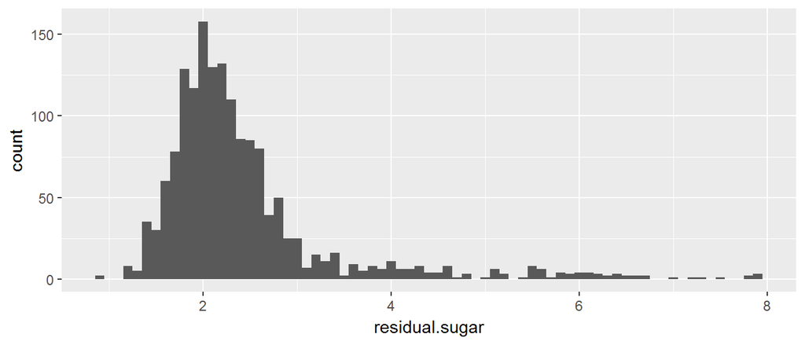

```
## [1] 182
```

#### **“chlorides” 氯化钠**

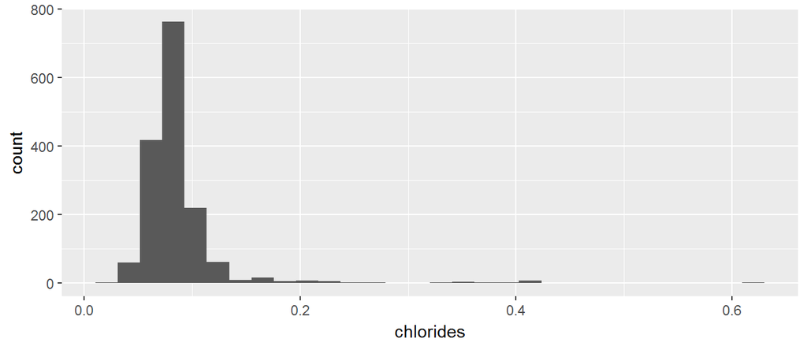

```
##    Min. 1st Qu.  Median    Mean 3rd Qu.    Max.
## 0.01200 0.07000 0.07900 0.08747 0.09000 0.61100
```

氯化钠含量的分布也不均匀，最大值为0.61，中位数仅为0.079。IQR = 0.02，大于0.12小于0.04的数据为异常值。

```
## [1] 100
```

```
## [1] 9
```

异常值数量：  
大于0.12：100个；小于0.04：9个  
剔除异常值再作图：

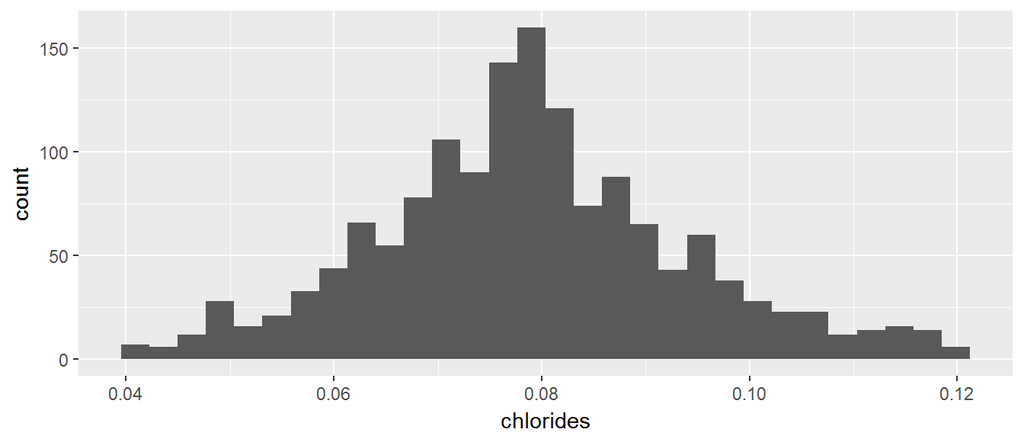

近似正态分布

#### **“free.sulfur.dioxide” 游离二氧化硫**

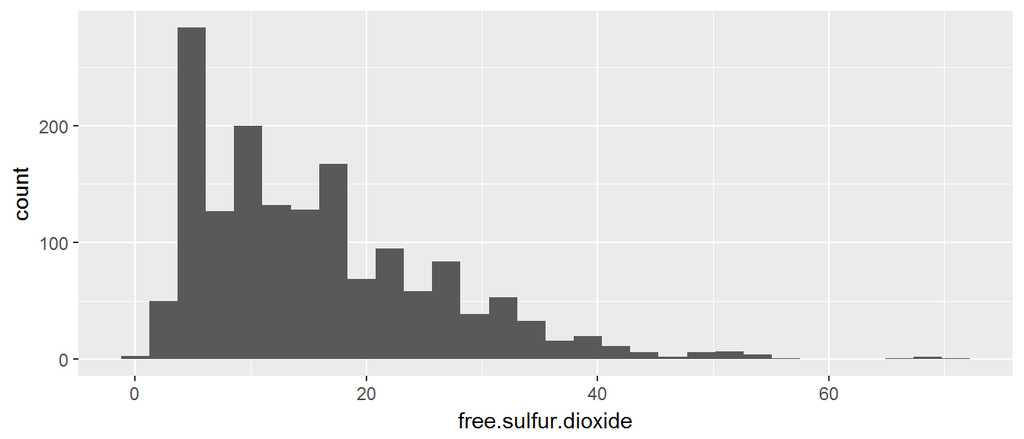

```
##    Min. 1st Qu.  Median    Mean 3rd Qu.    Max.
##    1.00    7.00   14.00   15.87   21.00   72.00
```

正偏斜分布

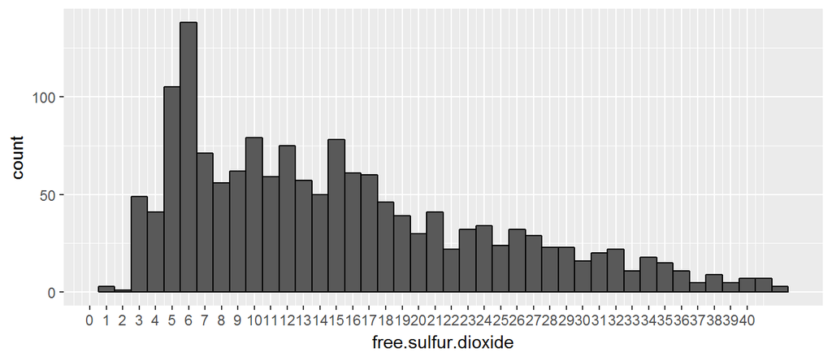

剔除异常值，改变柱的宽度为1，可以看到游离二氧化硫含量为5mg/m^3 和6mg/m^3的红葡萄酒数量最多。

#### **“total.sulfur.dioxide” 总二氧化硫**

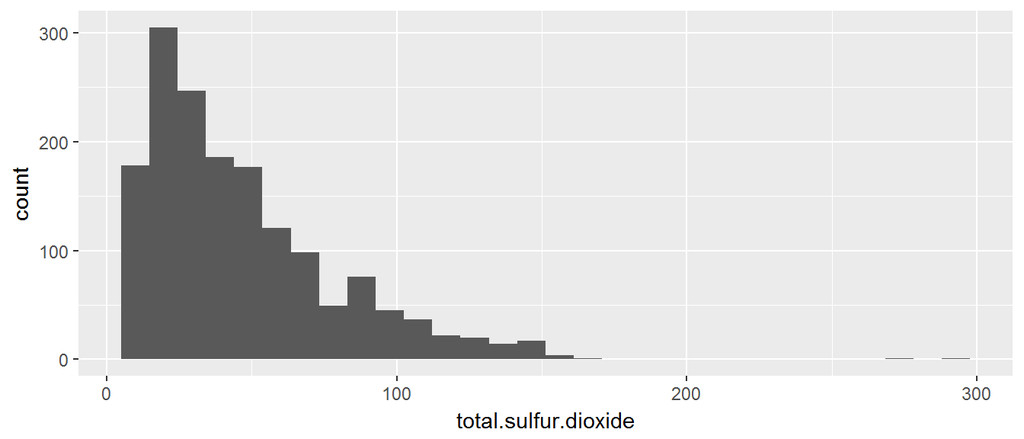

[output not shown]

含有异常值的正偏斜分布，剔除异常值，作图如下：

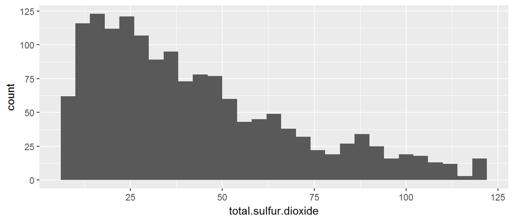

#### **“density” 密度**

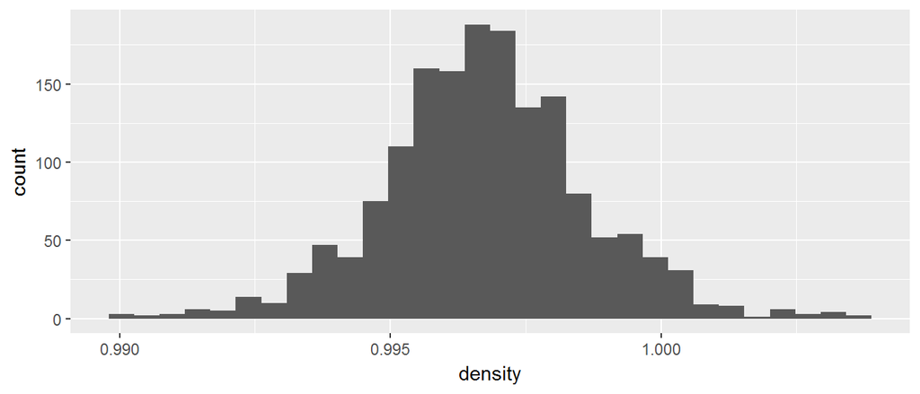

```
##    Min. 1st Qu.  Median    Mean 3rd Qu.    Max.
##  0.9901  0.9956  0.9968  0.9967  0.9978  1.0040
```

密度近似正态分布，均值为0.9967,中位数为0.9968，二者非常接近。

#### **“pH”值**

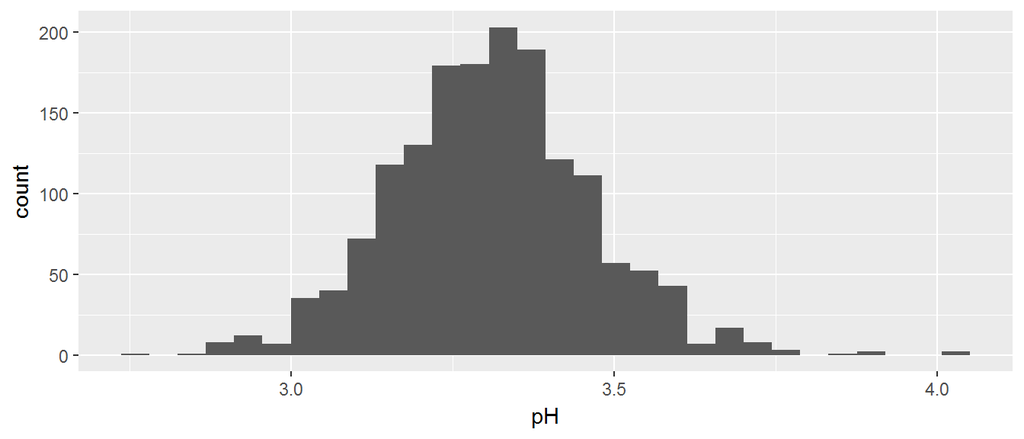

```
##    Min. 1st Qu.  Median    Mean 3rd Qu.    Max.
##   2.740   3.210   3.310   3.311   3.400   4.010
```

PH值近似正态分布，均值为3.311，中位数为3.310，二者非常接近。

#### **“sulphates”硫酸钾**

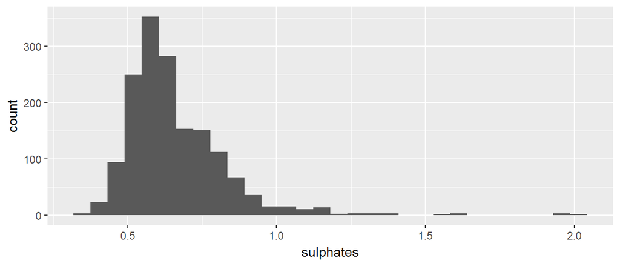

```
##    Min. 1st Qu.  Median    Mean 3rd Qu.    Max.
##  0.3300  0.5500  0.6200  0.6581  0.7300  2.0000
```

剔除异常值后，如下图所示

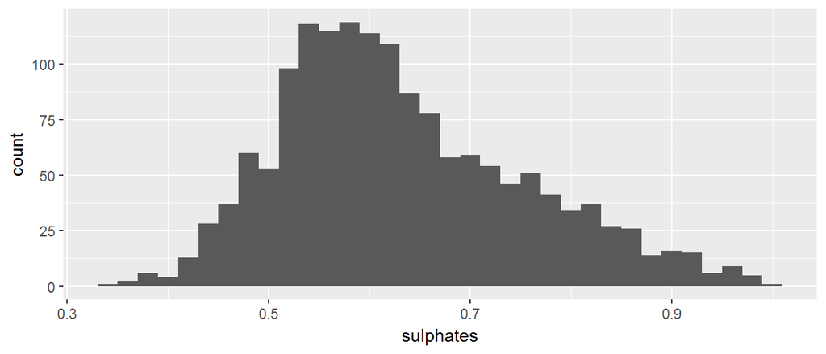

正偏斜分布

#### **“alcohol”酒精含量**

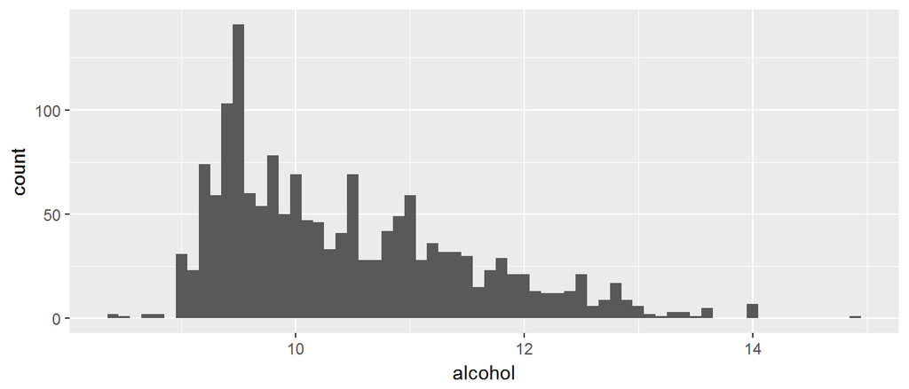

```
##    Min. 1st Qu.  Median    Mean 3rd Qu.    Max.
##    8.40    9.50   10.20   10.42   11.10   14.90
```

正偏斜分布

#### **创建一个新的变量——酒精浓度区间rw$alcohol_class**

```
## 'data.frame':    1599 obs. of  14 variables:
##  $ X                   : int  1 2 3 4 5 6 7 8 9 10 ...
##  $ fixed.acidity       : num  7.4 7.8 7.8 11.2 7.4 7.4 7.9 7.3 7.8 7.5 ...
##  $ volatile.acidity    : num  0.7 0.88 0.76 0.28 0.7 0.66 0.6 0.65 0.58 0.5 ...
##  $ citric.acid         : num  0 0 0.04 0.56 0 0 0.06 0 0.02 0.36 ...
##  $ residual.sugar      : num  1.9 2.6 2.3 1.9 1.9 1.8 1.6 1.2 2 6.1 ...
##  $ chlorides           : num  0.076 0.098 0.092 0.075 0.076 0.075 0.069 0.065 0.073 0.071 ...
##  $ free.sulfur.dioxide : num  11 25 15 17 11 13 15 15 9 17 ...
##  $ total.sulfur.dioxide: num  34 67 54 60 34 40 59 21 18 102 ...
##  $ density             : num  0.998 0.997 0.997 0.998 0.998 ...
##  $ pH                  : num  3.51 3.2 3.26 3.16 3.51 3.51 3.3 3.39 3.36 3.35 ...
##  $ sulphates           : num  0.56 0.68 0.65 0.58 0.56 0.56 0.46 0.47 0.57 0.8 ...
##  $ alcohol             : num  9.4 9.8 9.8 9.8 9.4 9.4 9.4 10 9.5 10.5 ...
##  $ quality             : int  5 5 5 6 5 5 5 7 7 5 ...
##  $ alcohol_class       : Factor w/ 7 levels "(8,9]","(9,10]",..: 2 2 2 2 2 2 2 2 2 3 ...
```

我创建了一个新的变量alcohol_class，它把酒精浓度区间分成了7个，即(8,9],(9,10],(10,11],(11,12],(12,13],(13,14],(14,15] # **Univariate Analysis 单变量分析**

### 最感兴趣的数据集的主要变量是什么？

我对红酒的“质量分数”最感兴趣。我想知道究竟是哪些化学成分影响了红酒的质量分数。是否可以建立数学模型来预测红酒的质量分数？

### 你认为哪些变量可以帮助你开展研究？

我个人觉得，残留糖（甜味）、氯化钠（鲜味）、柠檬酸（酸味）、醋酸（酸味）、酒精浓度这些我比较熟悉的化学成分,可能会影响红酒的口感，进而影响红酒的分数。

### 是否从原有变量中创建新的变量？

我新建了一个变量叫alcohol_class，就是把酒精浓度划分成了7个区间，比如9.9%，区间为(9,10]。这样做的好处是：在后面多变量的可视化时候，可以方便的用不用颜色代表酒精浓度。

### 数据集中是否有非常规的数据分布？你对数据进行了整理或者改变数据类型了吗？如果有，为什么要这么做？

# Bivariate Plots Section 双变量作图部分

#### **相关系数矩阵**

```
##                      fixed.acidity volatile.acidity citric.acid residual.sugar chlorides free.sulfur.dioxide
## fixed.acidity               1.0000         -0.25613      0.6717        0.11478   0.09371            -0.15379
## volatile.acidity           -0.2561          1.00000     -0.5525        0.00192   0.06130            -0.01050
## citric.acid                 0.6717         -0.55250      1.0000        0.14358   0.20382            -0.06098
## residual.sugar              0.1148          0.00192      0.1436        1.00000   0.05561             0.18705
## chlorides                   0.0937          0.06130      0.2038        0.05561   1.00000             0.00556
## free.sulfur.dioxide        -0.1538         -0.01050     -0.0610        0.18705   0.00556             1.00000
## total.sulfur.dioxide       -0.1132          0.07647      0.0355        0.20303   0.04740             0.66767
## density                     0.6680          0.02203      0.3649        0.35528   0.20063            -0.02195
## pH                         -0.6830          0.23494     -0.5419       -0.08565  -0.26503             0.07038
## sulphates                   0.1830         -0.26099      0.3128        0.00553   0.37126             0.05166
## alcohol                    -0.0617         -0.20229      0.1099        0.04208  -0.22114            -0.06941
## quality                     0.1241         -0.39056      0.2264        0.01373  -0.12891            -0.05066
##                      total.sulfur.dioxide density      pH sulphates alcohol quality
## fixed.acidity                     -0.1132  0.6680 -0.6830   0.18301 -0.0617  0.1241
## volatile.acidity                   0.0765  0.0220  0.2349  -0.26099 -0.2023 -0.3906
## citric.acid                        0.0355  0.3649 -0.5419   0.31277  0.1099  0.2264
## residual.sugar                     0.2030  0.3553 -0.0857   0.00553  0.0421  0.0137
## chlorides                          0.0474  0.2006 -0.2650   0.37126 -0.2211 -0.1289
## free.sulfur.dioxide                0.6677 -0.0219  0.0704   0.05166 -0.0694 -0.0507
## total.sulfur.dioxide               1.0000  0.0713 -0.0665   0.04295 -0.2057 -0.1851
## density                            0.0713  1.0000 -0.3417   0.14851 -0.4962 -0.1749
## pH                                -0.0665 -0.3417  1.0000  -0.19665  0.2056 -0.0577
## sulphates                          0.0429  0.1485 -0.1966   1.00000  0.0936  0.2514
## alcohol                           -0.2057 -0.4962  0.2056   0.09359  1.0000  0.4762
## quality                           -0.1851 -0.1749 -0.0577   0.25140  0.4762  1.0000
```

#### **散点图矩阵**

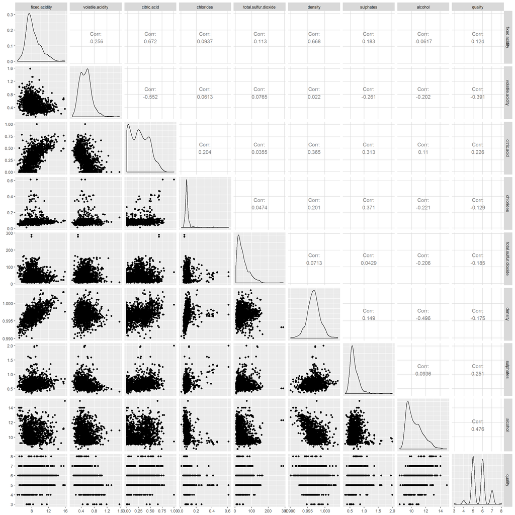

通过散点图矩阵可知，酒精含量和质量分数之间存在正相关性（相关系数为0.47）；醋酸含量和质量分数存在负相关（相关系数是-0.391），有可能是醋酸含量过高会使人感到不适，所以影响评分。上图中也验证了，酒石酸和密度之间的正相关、醋酸和柠檬酸的负相关、酒石酸和柠檬酸正相关等关系。由于散点矩阵图过小，而且点之间有重叠，有必要重点分析酒精含量、醋酸含量、硫酸钾（相关系数0.25）、柠檬酸（相关系数0.23）与质量分数的撒点图。

#### **“酒精浓度—质量分数”散点图**

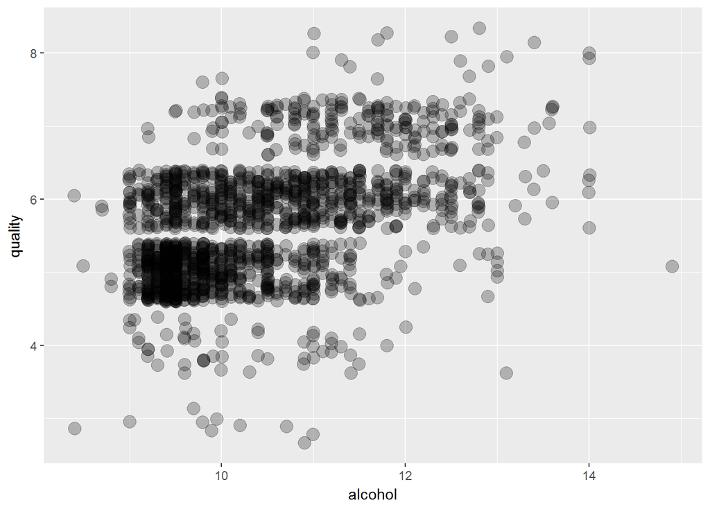

为了方便观察，我将点的深度改为0.25，并且对点的位置进行抖动。从图中可以看出，大部分的点的酒精含量为9%~11%之间，分数集中在5分和6分；随着酒精浓度上升，质量分数也响应提高。得8分的红酒的酒精浓度大多在11%以上。得3分红酒的酒精浓度都小于等于11%。

```
##
## Calls:
## m: lm(formula = quality ~ alcohol, data = rw)
##
## =============================
##   (Intercept)      1.875***
##                   (0.175)
##   alcohol          0.361***
##                   (0.017)
## -----------------------------
##   R-squared           0.227
##   adj. R-squared      0.226
##   sigma               0.710
##   F                 468.267
##   p                   0.000
##   Log-likelihood  -1721.057
##   Deviance          805.870
##   AIC              3448.114
##   BIC              3464.245
##   N                1599
## =============================
```

通过计算R^2 ,质量分数中有22.7%是由酒精浓度引起的。

#### **“醋酸—质量分数”散点图**

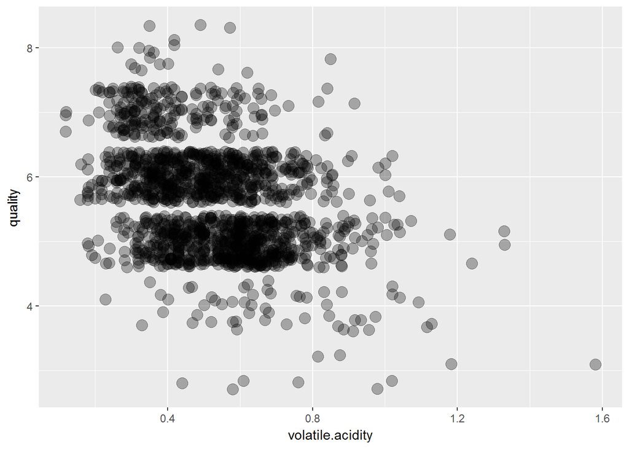

可以从图中看出负相关的关系

```
##
## Calls:
## m: lm(formula = quality ~ volatile.acidity, data = rw)
##
## ===============================
##   (Intercept)        6.566***
##                     (0.058)
##   volatile.acidity  -1.761***
##                     (0.104)
## -------------------------------
##   R-squared             0.153
##   adj. R-squared        0.152
##   sigma                 0.744
##   F                   287.444
##   p                     0.000
##   Log-likelihood    -1794.312
##   Deviance            883.198
##   AIC                3594.624
##   BIC                3610.756
##   N                  1599
## ===============================
```

#### **“硫酸钾—质量分数”散点图**

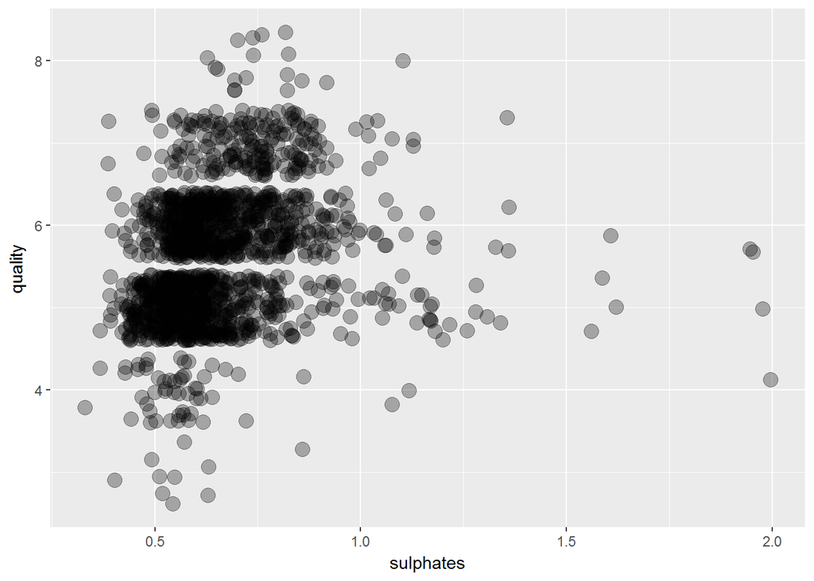

可以从图中看出正相关关系，但当硫酸钾含量大于1.0g/dm^3以后，质量分数相应的降低了。剔除硫酸钾含量的异常值作图如下：

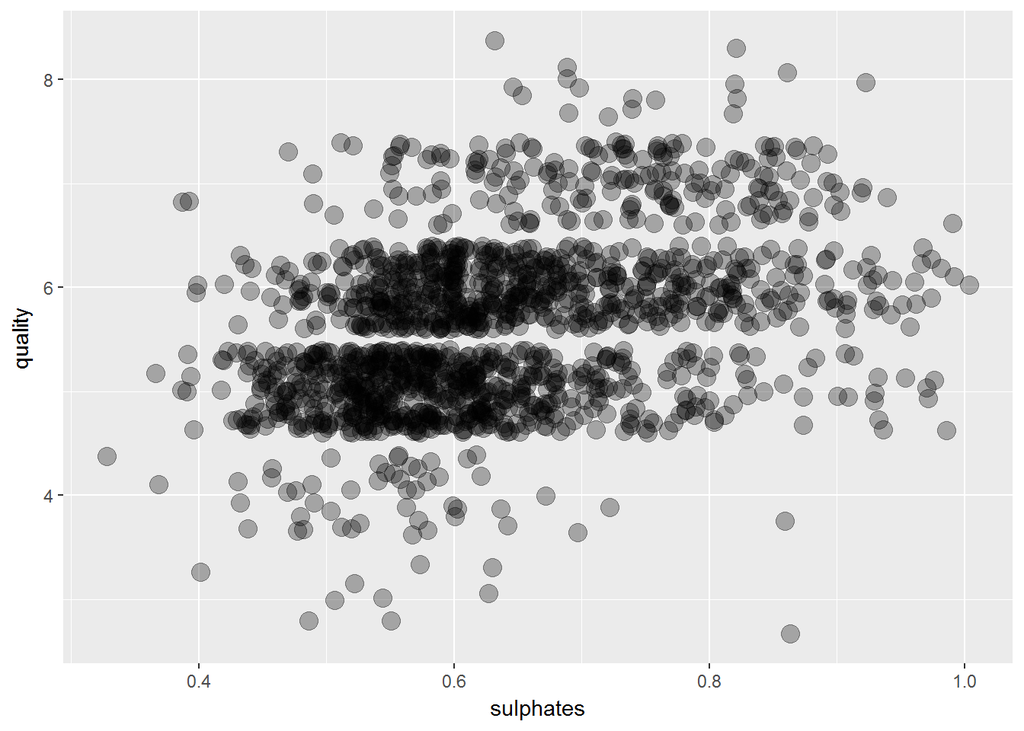

从图中可以看出，得8分的红葡萄酒的硫酸钾含量都在0.6g/dm<sup>3~1.0g/dm</sup>3之间。

```
##
## Calls:
## m: lm(formula = quality ~ sulphates, data = rw)
##
## =============================
##   (Intercept)      4.848***
##                   (0.078)
##   sulphates        1.198***
##                   (0.115)
## -----------------------------
##   R-squared           0.063
##   adj. R-squared      0.063
##   sigma               0.782
##   F                 107.740
##   p                   0.000
##   Log-likelihood  -1874.438
##   Deviance          976.300
##   AIC              3754.876
##   BIC              3771.008
##   N                1599
## =============================
```

通过计算R^2 ,质量分数中有6.3%是由硫酸钾引起的。

#### **“柠檬酸—质量分数”散点图**

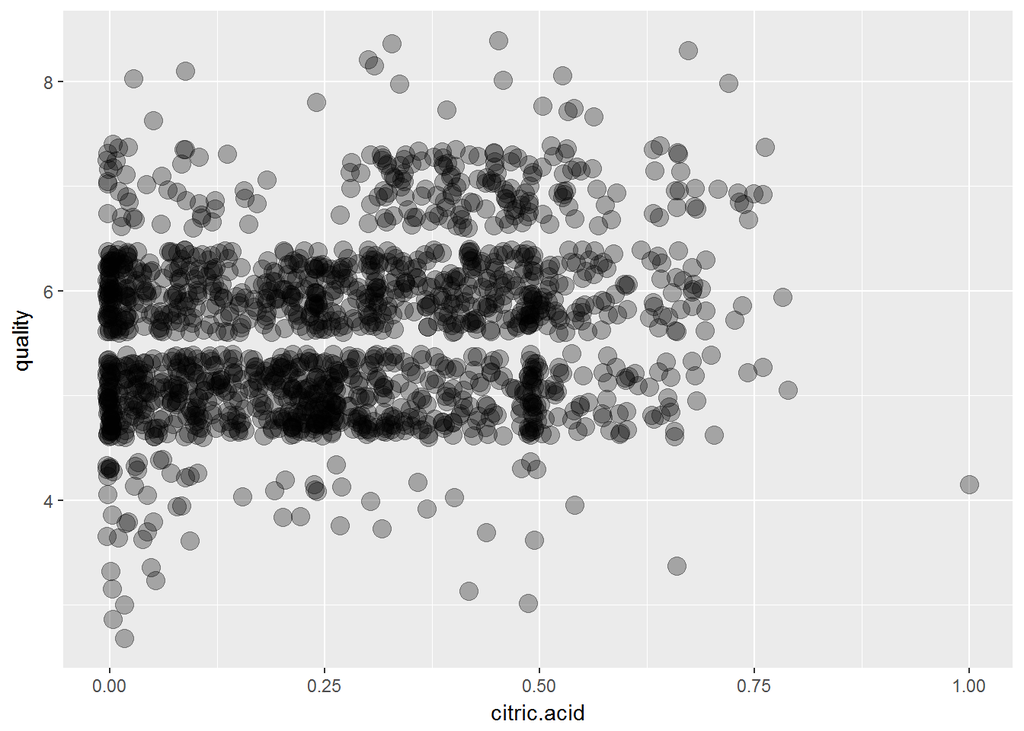

可以从图中看出是正相关关系。

```
##
## Calls:
## m: lm(formula = quality ~ citric.acid, data = rw)
##
## =============================
##   (Intercept)      5.382***
##                   (0.034)
##   citric.acid      0.938***
##                   (0.101)
## -----------------------------
##   R-squared           0.051
##   adj. R-squared      0.051
##   sigma               0.787
##   F                  86.258
##   p                   0.000
##   Log-likelihood  -1884.577
##   Deviance          988.760
##   AIC              3775.155
##   BIC              3791.286
##   N                1599
## =============================
```

通过计算R^2 ,质量分数中有5.1%是由柠檬酸引起的。

#### **“酒石酸—PH值”散点图**

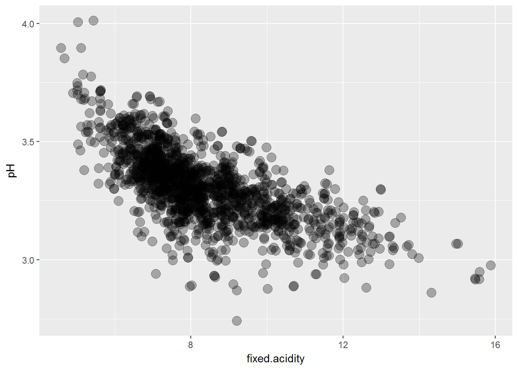

可以看到酒石酸含量越高，pH值越低。

#### **“酒石酸—密度”散点图**

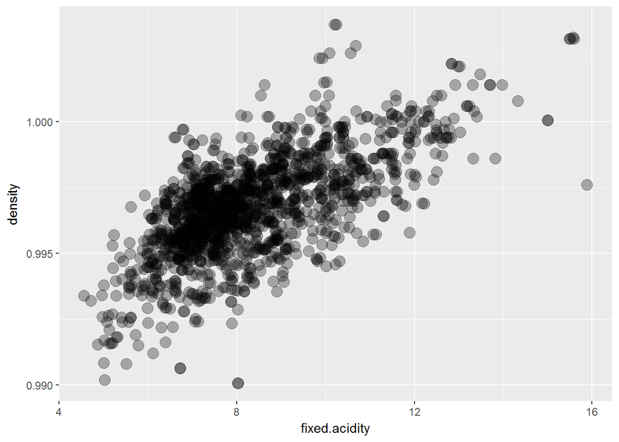

可以看到酒石酸含量越高，密度越高。

# 双变量分析

### 谈一谈你在双变量研究中的发现，你关心的变量与其他参数之间有什么关系？

我发现酒精含量、醋酸含量、硫酸钾、柠檬酸与质量分数相关性最高。  
- 酒精含量越高，质量分数越高；  
- 醋酸含量越高，质量分数越低；  
- 硫酸钾含量越高，质量分数越高；  
- 柠檬酸含量越高，质量分数越高；

### 你还发现其他一些有意思的参数关系了吗？

酒石酸含量越高，pH值越低；酒石酸含量越高，密度越高。

### 你发现的最强的相关关系是什么？

我发现，质量分数与酒精含量相相关性最高，酒精含量高的红酒，得分都较高。得8分的红酒的酒精浓度大多在11%以上。得3分红酒的酒精浓度都<=11%。实际上，葡萄酒在发酵过程中，糖分转化成酒精，含糖量越高，酒精含量也越高，但毕竟是果酒，超过15%是非常困难的，所以世界顶级的葡萄酒庄园都在努力提高葡萄的含糖量。 但是，通过“酒精含量—质量分数”散点图，我还是很难判断用什么样的曲线来拟合，因为82%的红酒得分都在5分或者6分。通过计算R^2 ,质量分数中有22.7%是由酒精含量引起的。我认为问题就在于：红酒品评师打分会取整数。如果可以给出带有小点后1位的分数（比如5.2分，5.5分），数据分布就会连续的多。

# 多变量作图部分

#### 柠檬酸—酒精浓度—质量分数

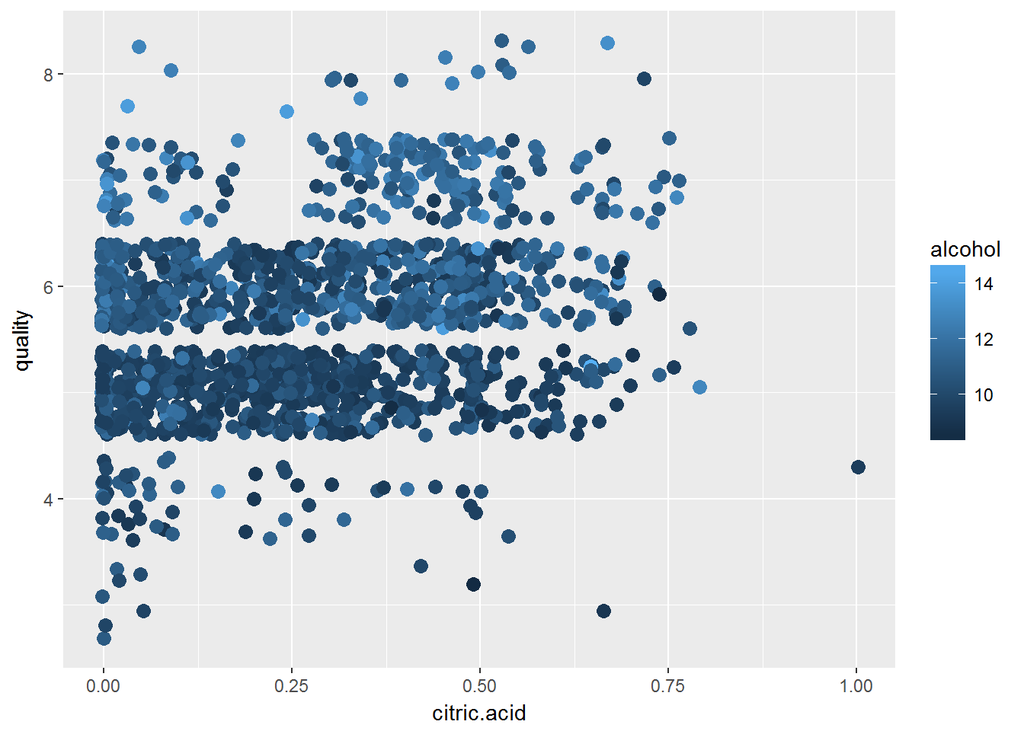

图中圆点的颜色越深，酒精含量越低；圆点颜色越浅，酒精含量越高。浅色的圆点多集中在图的上部，深色的圆点多集中在图的下部。说明酒精含量高，得分就高。另外，随着柠檬酸含量的提高，质量分数也有提高的趋势。但是上面的图，由于酒精浓度是用深浅表示，区别并不明显，下面用我创建的新的变量alcohol_class，来代替alcohol。

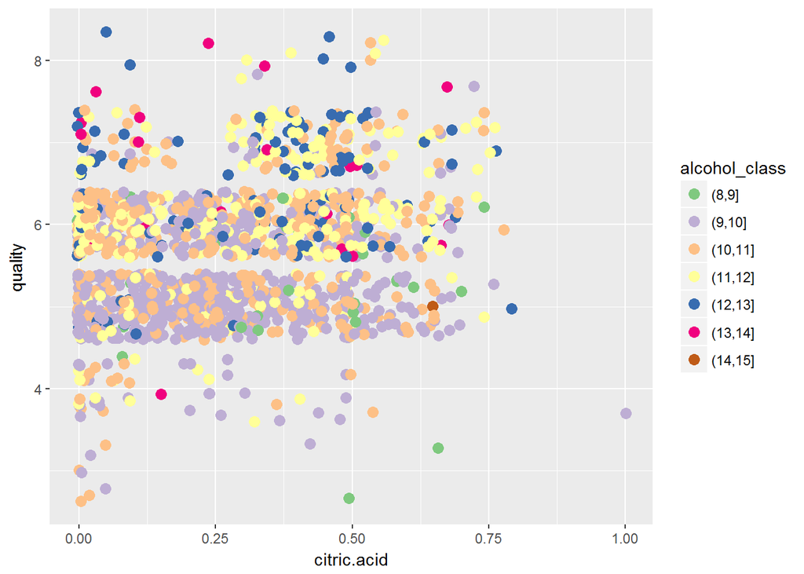

图中，红色，蓝色的圆点表示酒精浓度高，多集中在图的上部；橙色、淡紫色的点表示酒精浓度低，多集中在图的下部。

#### 硫酸钾—酒精浓度—质量分数

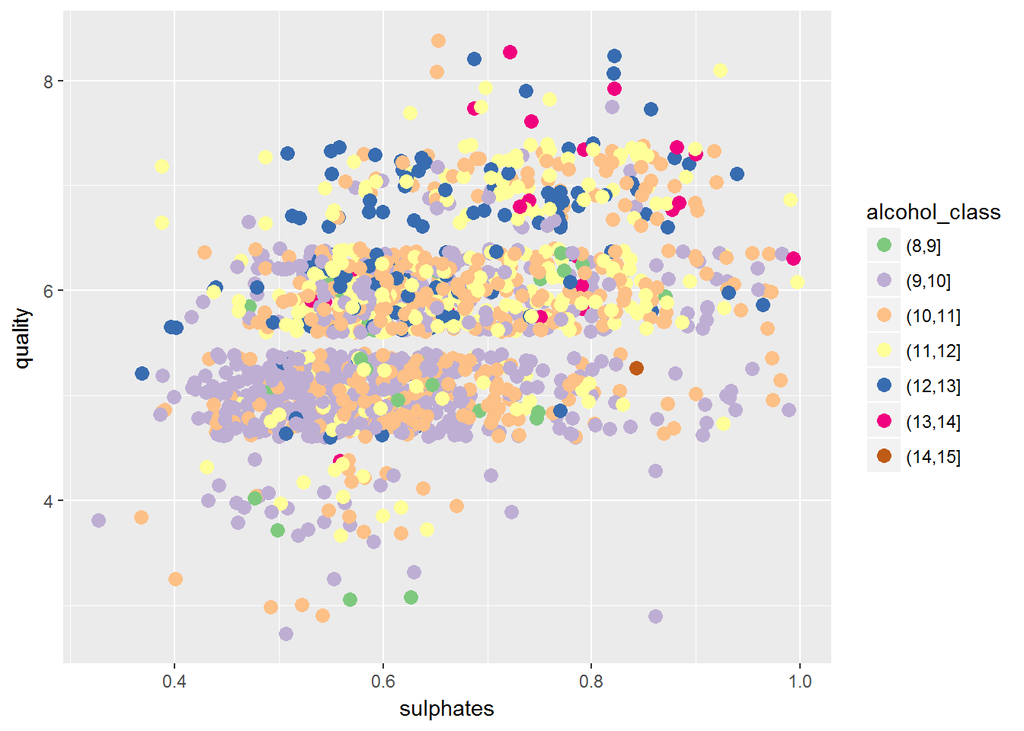

我开始挺奇怪，硫酸钾怎么会对酒的质量评分有影响？后来查阅资料发现，硫酸钾可提高二氧化硫气体的浓度进而抑制微生物和抗氧化。可能葡萄酒的微生物少，口感也就好。上图中的蓝色、红色圆点代表酒精浓度高，多集中在图的上部，即红葡萄酒的质量分数高。

#### 柠檬酸—醋酸—酒精浓度—质量分数

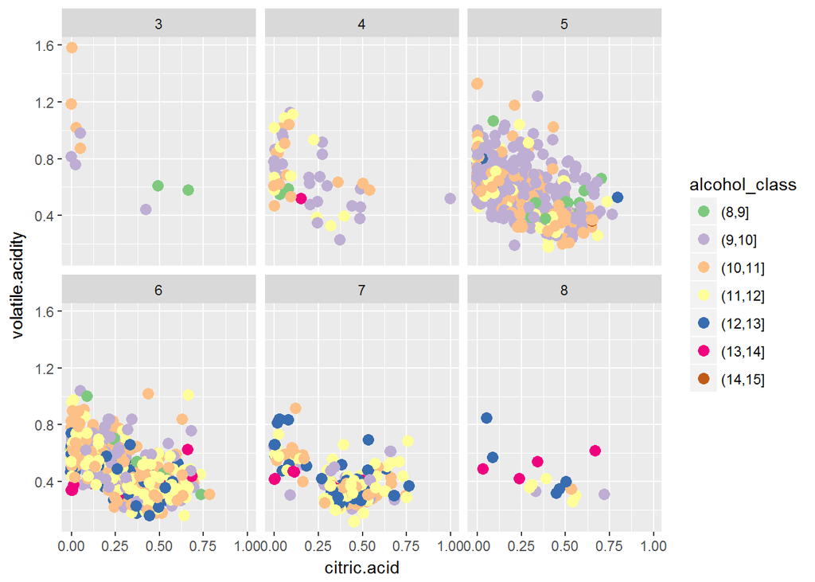

6张图代表6种不同的质量分数；横坐标是柠檬酸，纵坐标是醋酸；令人奇怪的是,每张图都表现了随着柠檬酸含量的提高，醋酸的含量就会降低的趋势。由于柠檬酸和醋酸这种相关性，在后面的数学建模时，这两个参数不宜同时使用。  
点大多集中在5分和6分这两幅图中。代表酒精浓度高的点大多集中在6分、7分、8分这3张图上；相反，3分、4分图上的点的颜色大多数代表酒精浓度低。

#### 建立数学模型

```r
m1 <- lm(I(quality) ~ I(alcohol), data = rw)
m2 <- update(m1, ~ . + volatile.acidity)
m3 <- update(m2, ~ . + sulphates)
mtable(m1, m2, m3,sdigits = 4)
```

```
##
## Calls:
## m1: lm(formula = I(quality) ~ I(alcohol), data = rw)
## m2: lm(formula = I(quality) ~ I(alcohol) + volatile.acidity, data = rw)
## m3: lm(formula = I(quality) ~ I(alcohol) + volatile.acidity + sulphates,
##     data = rw)
##
## ========================================================
##                         m1          m2          m3
## --------------------------------------------------------
##   (Intercept)        1.875***    3.095***    2.611***
##                     (0.175)     (0.184)     (0.196)
##   I(alcohol)         0.361***    0.314***    0.309***
##                     (0.017)     (0.016)     (0.016)
##   volatile.acidity              -1.384***   -1.221***
##                                 (0.095)     (0.097)
##   sulphates                                  0.679***
##                                             (0.101)
## --------------------------------------------------------
##   R-squared             0.2267      0.3170      0.3359
##   adj. R-squared        0.2263      0.3161      0.3346
##   sigma                 0.7104      0.6678      0.6587
##   F                   468.2670    370.3790    268.9123
##   p                     0.0000      0.0000      0.0000
##   Log-likelihood    -1721.0568  -1621.8138  -1599.3842
##   Deviance            805.8705    711.7962    692.1046
##   AIC                3448.1135   3251.6275   3208.7683
##   BIC                3464.2449   3273.1360   3235.6540
##   N                  1599        1599        1599
## ========================================================
```

数学模型选取了3个参数来对质量分数进行预测：酒精含量、醋酸含量、硫酸钾来进行分析。得到只有33.6%对质量分数有贡献，显然这个数学模型精度是很低的。